# List of Trainings

Joao Luiz D’Andrea

2022-05-18

I can resume all this learning experience as “Discipline”. Motivation makes you start discipline moves you to the end.

## Training per Area

What you will see below is a list of training I did to support my professional life as an Information technology Project Manager. When you work as a consultant in the enterprise is important to know about the best practices in IT Governance, Project Management and the trending technologies.

Not to micromanage but to see with others can’t. Proactively avoiding problems and mitigating risks. “You can’t control what you can’t measure” – Tom DeMarco.

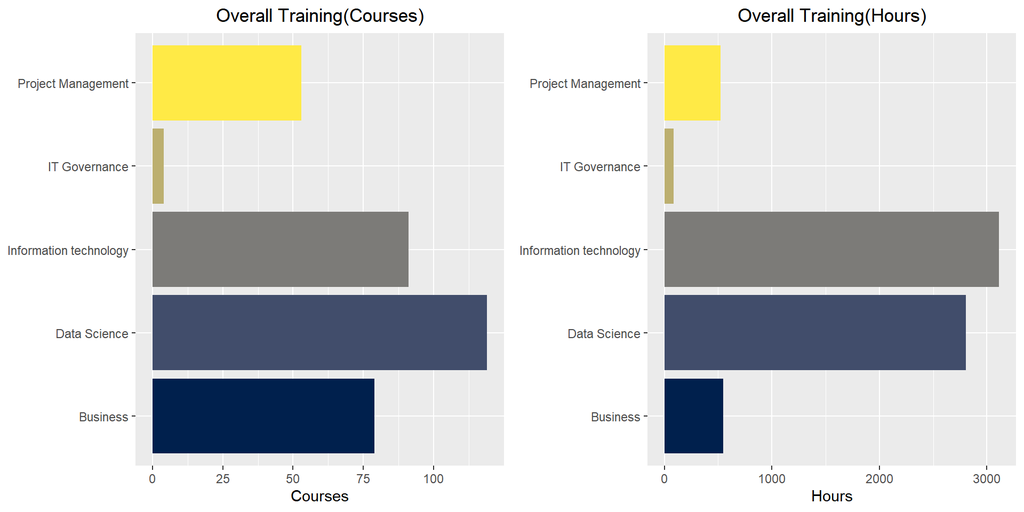

## Governance in Information Technology

Know IT Governance is important to feel the context we are inserted. Projects must be Planned, Executed, Controlled and Closed with this in mind. At the end the project must fit in the Governance in place considering, people, polices and frameworks, processes, organizational structures, culture, ethics and behavior, information, services, Infrastructure and applications.

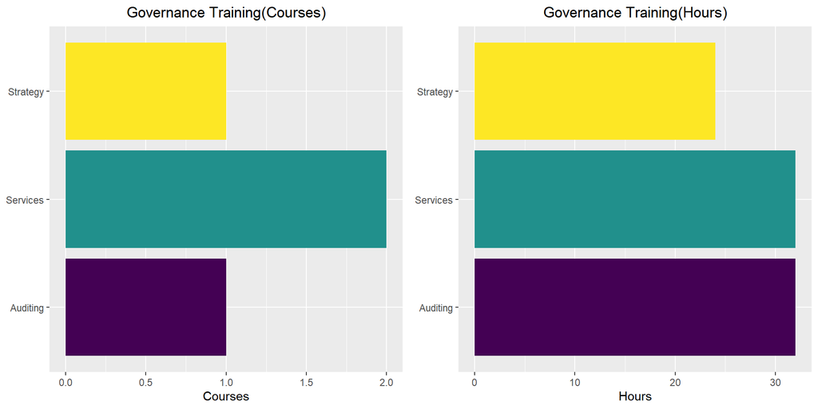

|  | Course | Skills | Date | Instructor | Company | Total |
| --- | --- | --- | --- | --- | --- | --- |
| 1 | CISA Certified Information System Auditor | Auditing |  | Joseph | Knowledge Academy | 32 |
| 2 | ITIL Foundation | Services | 2015-10-01 | Mark Thomas | Lynda | 8 |
| 3 | ITIL Foundation Certification | Services | 2011-10-01 |  | Thougth Rock | 24 |
| 4 | COBIT5 - Control Objectives for Information Technology | Strategy |  |  | Knowledge Academy | 24 |

## Project Management

Project Management is about Servant Leadership it means be open to do your best to remove any impediments we as a team have to deliver the outcome.

The best practices like **PRINCE2**, **PMBOK**, and agile practices like **Scrum**, **Kanban** must be known. Keep in mind we are free to adapt and improve to our own needs. “Methodologies are treks not rails” - Joao Luiz D’Andrea

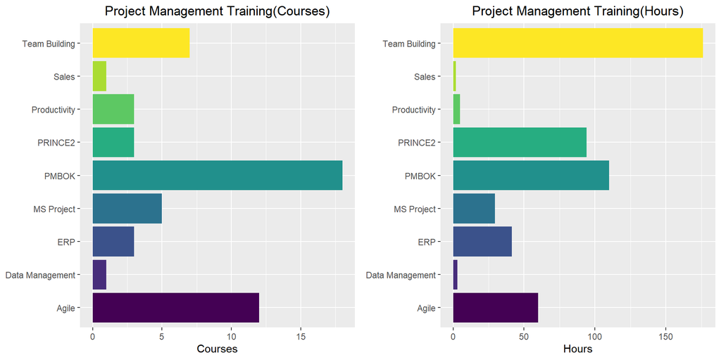

|  | Course | Skills | Date | Instructor | Company | Total |
| --- | --- | --- | --- | --- | --- | --- |
| 1 | Agile at Work Building Your Agile Team | Agile | 2015-09-01 | Doug Rose | Linkedin | 2 |
| 2 | Agile at Work Planning With Agile User Stories | Agile | 2015-06-01 | Doug Rose | Linkedin | 1 |
| 3 | Agile at Work: Driving Productive Agile Meetings | Agile | 2016-05-01 | Doug Rose | Linkedin | 1 |
| 4 | Agile Project Management | Agile |  | Bob McGannon | Linkedin | 1 |
| 5 | Agile Project Management With a Microsoft Project | Agile | 2015-06-01 | Bonnie Biafore | Linkedin | 2 |
| 6 | Agile Transformation and Scale Agile | Agile |  | ICAN Consultancy |  | 4.5 |
| 7 | Managing Small Projects | Agile |  | Bonnie Biafore | Linkedin | 1.5 |
| 8 | Managing Technical Teams | Agile |  | Bob McGannon | Linkedin | 1 |
| 9 | Practical Project Management for Creative Projects | Agile | 2015-05-01 | Jeff Blomfield | Linkedin | 3 |
| 10 | Transitioning Waterfall to Agile Project Management | Agile | 2015-10-01 | Kelley O'Connel | Linkedin | 2 |

[output cut: 43 more lines]

## Information Technology

I love technology and how affect the business and our day-by-day activities and change the world. That was my motivation when I started my way in IT.

Update with the new releases of ERP and CRM Software like SAP, Sales-force, Microsoft Dynamics 365.

It has been a life learning endeavor to keep up to date and have a deep understand of new technologies in special in the last ten year when infrastructure enable **Artificial Intelligence**, **Machine Learning**, **Block Chain** and the **Cloud** movement. In the table below we can see my effort in that direction learning: **Spark** (Spark SQL, Spark Graph-X, Spark ML, Spark Streaming), **Hadoop**, Ambary, HDFS, Map Reduce, Pig, Hive, Drill, Phoenix, Presto, Yarn, Messos, Zookeeper, Oozy, Zeppelin, Hue, **NIFI**,**Kafka**, Flume, Sqoop, Node-Red. No Relational Databases: **Hbase**, **MongoDB**, **Cassandra**.

Training by Skill

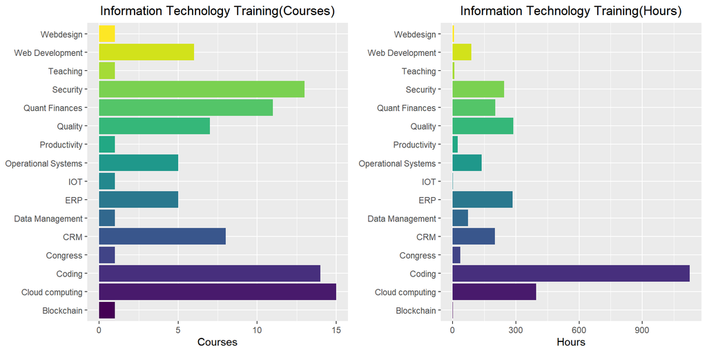

Training by Technology

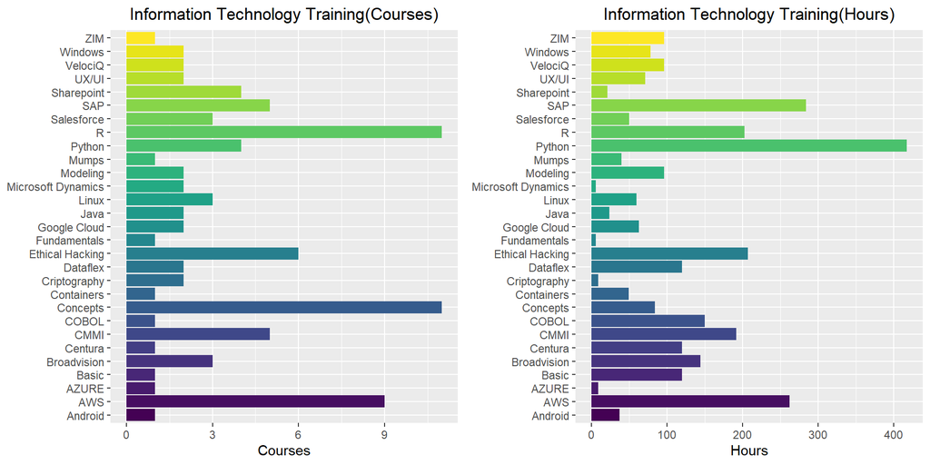

|  | Course | Skills | Technology | Date | Instructor | Company | Total |
| --- | --- | --- | --- | --- | --- | --- | --- |
| 1 | Block Chain Technology : A guide to the Block Chain | Blockchain | Concepts | 2017-06-01 | Ravinder Deol | Udemy | 1 |
| 2 | Amazon AWS Associate Solution Architect | Cloud computing | AWS | 2018-05-01 | Ryan Kroonenberg | Udemy | 31 |
| 3 | Amazon webservices Data Services | Cloud computing | AWS | 2016-04-01 | Lynn Langit | Linkedin | 15 |
| 4 | Amazon webservices for Data Science | Cloud computing | AWS | 2016-10-01 | Lynn Langit | Linkedin | 12 |
| 5 | AWS Associate Developer Associate 2020 | Cloud computing | AWS | 2020-12-01 | Stephane Maarek | Udemy | 54.5 |
| 6 | AWS Certified Security Specialty | Cloud computing | AWS |  | Chandra Lingan | Udemy | 35 |
| 7 | AWS Cloud Formation Masterclass | Cloud computing | AWS |  | Stephane Maarek | Udemy | 7.5 |
| 8 | Developer to Architect: Mastering Software Architecture | Cloud computing | AWS |  | Anurag Yadav | Udemy | 51 |
| 9 | Ultimate AWS Certified Solution Architect 2020 | Cloud computing | AWS | 2020-02-01 | Stephane Maarek | Udemy | 27 |
| 10 | Ultimate AWS Solutions Architect Professional 2021 | Cloud computing | AWS |  | Stephane Maarek | Udemy | 29 |

[output cut: 81 more lines]

## Data Science & Big Data

In this section we can see the training I did to deep dive in Artificial Intelligence and Machine Learning. Writing code in **R**, **Python** using tools like **Spark**, **Kera’s**, **Theano**, **TensorFlow**, **H20**, **Tableau**, **Power BI**.

Machine Learning Algorithms for *Regression*: Simple Linear Regression, Multiple Linear Regressions, Polynomial Regression, Support Vector Regression (SVR), Decision Tree, Random Forest, XGBoost, Catboost, Lightgbm. *Classification*: Logistic Regression, K-Nearest Neighbours (K-NN), Support Vector Machine (SVM), Kernel SVM, Naïve Bayes, Decision Tree Classification, Random Forests Classification, XGBoost, Cat Boost. *Clustering*: K-Means Clustering, Hierarchical Clustering. *Association Rule* (Basket Analysis): Apriori, Ecla. *Reinforcement Learning*: Upper Confidence Bound (UCB), Thompson Sampling, QQ-Learning. NLP - Natural Language Processing. *Dimensionality Reduction*: Principal Component Analysis (PCA), Linear Discriminant Analysis (LDA), Kernel (PCA), *Model Selection and Boosting*: K-Fold Cross Validation, Grid Search. *Artificial Intelligence*: Q-Learning, Convolutional Neural Networks, Q-Learning, YOLO5, Computer Vision, Object Recognition. Cloud Environment: Amazon-AWS, Google Cloud, Databricks, AZURE.

Training by Skill

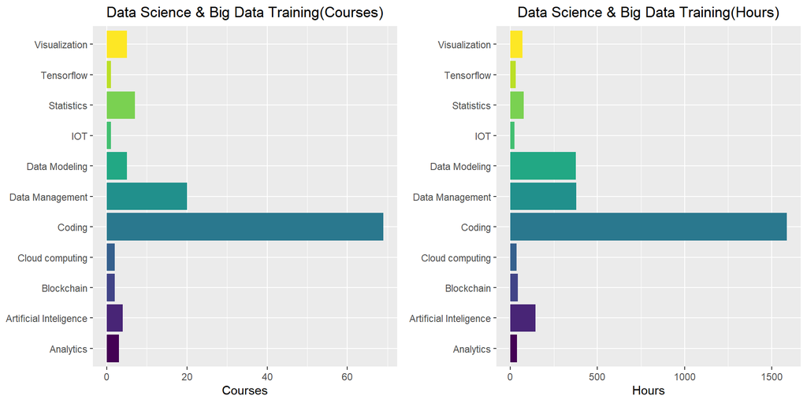

Training by Technology

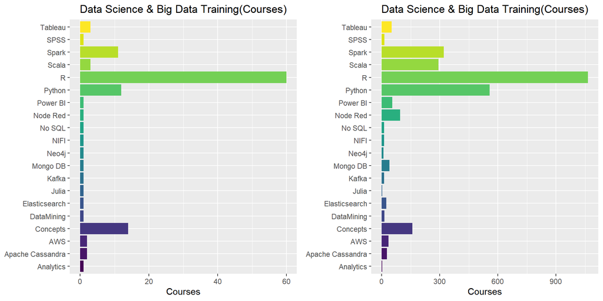

|  | Course | Skills | Technology | Date | Instructor | Company | Total |
| --- | --- | --- | --- | --- | --- | --- | --- |
| 1 | Foundations of Business Analytics: Prescritive Analitics | Analytics | Concepts | 2015-05-01 | Alan Simon | Linkedin | 9 |
| 2 | Introduction to Machine Learning | Analytics | R | 2014-01-11 | Vincent Vankrunkelsven | Data Camp | 18 |
| 3 | Machine Learning Toolbox | Analytics | R | 2014-01-12 | Zachary DeaneMayer | Data Camp | 12 |
| 4 | Advanced AI Deep Reinforcement Learning in Python | Artificial Inteligence | Python | 2017-07-01 | Lazy Programmer | Udemy | 13.5 |
| 5 | Artificial Inteligence AZ | Artificial Inteligence | Python | 2017-09-01 | Kiril Eremenko Hadelin de Ponteves | Super Data Science | 49.5 |
| 6 | Computer Vision AZ Open CV GUNS Cutting | Artificial Inteligence | Python | 2017-11-01 | Kiril Eremenko &amp; Hadelin de Ponteves | Super Data Science | 16.5 |
| 7 | Deep Learning AZ Python | Artificial Inteligence | Python | 2017-05-01 | Kiril Eremenko Hadelin de Ponteves | Super Data Science | 66 |
| 8 | Blockchain Beyond the Basics | Blockchain | Concepts | 2018-08-01 | Jonathan Reichental | Linkedin | 1.5 |
| 9 | Blockchain AZ | Blockchain | Python | 2018-04-03 | Kiril Eremenko &amp; Hadelin de Ponteves | Super Data Science | 41 |
| 10 | AWS Machine Learning AI SageMaker with python | Cloud computing | AWS | 2018-07-01 | Chandra Lingam | Udemy | 9 |

[output cut: 109 more lines]

## Business & Management

This is a couple of training in Business and Management like Marketing, Sales, Productivity, Team Building and related soft skills.

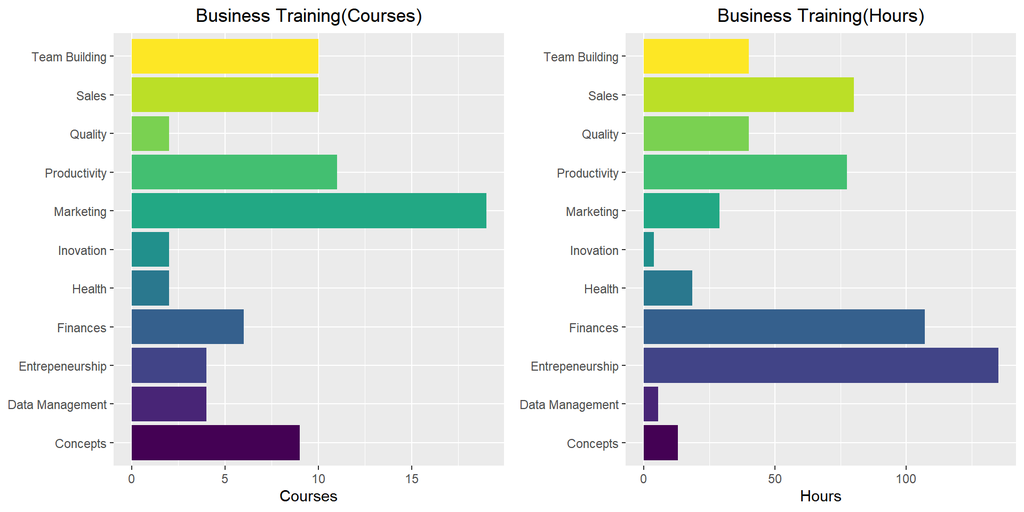

|  | Course | Date | Instructor | Company | Skills | Total |
| --- | --- | --- | --- | --- | --- | --- |
| 1 | Building Self Confidence | 2015-09-01 | Todd Duwett | Linkedin | Concepts | 1 |
| 2 | Business Writing Fundamentals |  | Judy SteinerWillians | Linkedin | Concepts | 1.5 |
| 3 | Humor in the Workspace | 2015-08-01 | Izzy Gessel | Linkedin | Concepts | 1 |
| 4 | Information Security &amp; Privacy Training Course | 2021-02-08 |  | Johnson&amp;Johnson | Concepts | 1 |
| 5 | Leading with Emotional Inteligence | 2015-06-01 | Britt Andreatta | Linkedin | Concepts | 2 |
| 6 | Learning to be Assertive | 2015-07-01 | Chris Croft | Linkedin | Concepts | 1 |
| 7 | Study Skills Fundamentals |  | Paul Nowak | Linkedin | Concepts | 1.5 |
| 8 | Writing Business Reports |  | Judy SteinerWillians | Linkedin | Concepts | 2 |
| 9 | Writing Research Papers | 2016-01-01 | Judy Steiner Willians | Linkedin | Concepts | 2 |
| 10 | EU Privacy Law &amp; AWS | 2019-01-01 |  | Udemy | Data Management | 1.5 |

[output cut: 69 more lines]